# evaluate_2_150_Ramus

```python
import numpy as np
import matplotlib.pyplot as pl

import tensorflow as tf
import tensorflow.keras.optimizers as optimizers

from model import *
from input import NetworkInput
from data import createFeaturesDescription
from config import *

from tensorflow.keras.models import Model

from datetime import datetime

from IPython.display import Audio
import soundfile as sf

import os
import json
import csv

import itertools

from tensorboard.plugins import projector

from sklearn import cluster

from scipy.cluster.hierarchy import dendrogram
```

### Configuration

```python
run_with_papermill=False

batch_size=16  #16  #512
stride=2
use_F0=False
F0_binary_values=False
use_deltas=False

hidden_size=128
num_layers=2

weights_filename='./logdir/2020-11-20_18-39-24-2_150_multiple_dropout/weights/weights_2020-11-20_18-39-24.h5'
weights_name='2_150_multiple_dropout'

useExScores=False
useRamus=False
use1dScores=False
useBalancedDataSet=False
balanced_dataset_folder='balanced_20_1'

evaluate_model=False
save_activations=False #save activations to json files  #mode ALL_CELLS or SELECTED_CELLS defined later
save_embeddings=True #save embeddings as checkpoint file (for tensorboard)
do_similarity_analyses=True
compute_confusion_matrix=False

embeddings_Hellinger=True  #embeddings based on sqrt of output


force_dropout=True #for embeddings, similarity analyses
force_dropout_conf_matrix=False #force dropout for confusion matrix
#For the examples of outputs, set manually
keep_prob=1
keep_prob_recurrent=1
keep_prob_dense_layer=1

#note: others useful parameters in rest of code, e.g. max_examples_language, max_batches for analyses

do_pairwise_analysis=False  #pairewise analysis inside every batch
```

```python
# Parameters
run_with_papermill = True
hidden_size = 150
use_deltas = True
use_F0 = True
F0_binary_values = True
useRamus = True
batch_size = 1
evaluate_model = True
save_activations = True
save_embeddings = False
compute_confusion_matrix = True
weights_filename = "./logdir/2021-08-19_14-53-14-2_150_mult_dropout_voiced_unvoiced_bis/weights/weights_2021-08-19_14-53-14.h5"
weights_name = "weights_2_150_voiced_unvoiced_bis"
```

```python
if not(run_with_papermill):  #manual settings
    force_dropout=True
    keep_prob=0.7
    keep_prob_dense_layer=0.9

    keep_prob_recurrent=0.9
    useBalancedDataSet=True
    #useRamus=True


    use_deltas=True
    hidden_size=150


    evaluate_model=False
    save_embeddings=False
    save_activations=True
    do_similarity_analyses=False

    compute_confusion_matrix=False
```

```python
weights_config={
    'num_steps':32,
    'features_description':createFeaturesDescription(F0=use_F0),
    'stride':stride
}
```

```python
load_weights=True

#old models (old inputs)
#1D models
#weights_filename="./models/weights0420/weights20epochs.h5"
#weights_filename, weights_name="./models/weights0420b/weights_2020-04-07_17-55-05.h5", "weights_2020-04-07"
#weights_config['features_description']=createFeaturesDescription(HRmsValue=False, F0=False)

#2D models
#weights_filename, weights_name='./models/weights0715-2d-60Hz/weights_2020-07-15_12-15-21.h5', 'weights0715-2d-60Hz'
#weights_filename, weights_name='./models/weights0717-2d-60Hz-64/weights_2020-07-17_17-35-40.h5', 'weights0717-2d-60Hz-64'
#weights_config['features_description']=createFeaturesDescription(F0=False)
#weights_config['stride']=1

#weights_filename, weights_name="./models/weights0710-3d/weights_2020-07-03_17-40-31.h5", "weights0710-3d"
```

```python
num_steps=weights_config["num_steps"]
features_description=weights_config['features_description']
stride=weights_config['stride']

if not(force_dropout or force_dropout_keep_prob_dense_layer):
    keep_prob_dense_layer=1
    keep_prob=1
config=Config(batch_size, num_steps, hidden_size=hidden_size,
              num_layers=num_layers,
              keep_prob=keep_prob, keep_prob_recurrent=keep_prob_recurrent,
              keep_prob_dense_layer=keep_prob_dense_layer)
config=completedConfig(config) #take default params for unspecified params
```

```
WARNING:root:No cell type specified in config: using LSTM
```

### Input

```python
languages = ["Danish", "Dutch", "English", "Finnish",
    "French", "German", "Hungarian", "Italian",
    "Japanese", "Korean", "Mandarin", "Polish",
    "Portuguese", "Russian", "Spanish",
    "Swedish", "Turkish", "Estonian", "Arabic", "Czech", "Romanian",
    "Basque", "Catalan"]  #NB: check that the order of elements is consistent with model

#Remove languages with not enough data
languages.remove("Czech")
languages.remove("Romanian")


#languages_dataset=languages+['Romanian'] #None -> autodetect,  languages-> same as model (defined above)
languages_dataset=None


#scores Folder #default: "./Scores"
assert useExScores^useRamus^use1dScores^useBalancedDataSet , "choose a unique dataset"

if useExScores:
    scores_folder='./ex_Scores'
elif useRamus:
    scores_folder='./Scores_Ramus'
elif use1dScores:
    scores_folder='./Scores_1d'
else:
    scores_folder='./Scores'

max_files_evaluation= 2024 #np.inf
# FIRST VERSION
#languages = ['Danish', 'Russian', 'Mandarin', 'Finnish', 'Dutch', 'English', 'Hungarian', 'Swedish',
#             'Italian', 'French', 'Japanese', 'German', 'Portuguese', 'Polish', 'Spanish', 'Korean']


sets ={}

set_folds=[0]

if useExScores or useRamus:
    sets_folds={"test":[0]}
elif useBalancedDataSet:
    sets_folds={"test":[0]} #subfolder defined later
else:
    sets_folds = {"train" : [0, 1, 2],
            "test":[3,4],
            "test1" : [3],
            "test2" : [4]}

initial_sample_length=3*2**14 if useRamus else 10*2**14
TFRecords_batch_size=1 if useRamus else 16
```

```python
set_name='train'
if set_name in sets_folds:
    if useRamus:
        subfolders=[""]
    elif useBalancedDataSet:
        subfolders=[balanced_dataset_folder]
    else:
        subfolders=["fold_{}/".format(k_fold) for k_fold in sets_folds[set_name]]
    sets[set_name] = NetworkInput(config, folder=scores_folder,
                         subfolder=subfolders,
                stride=stride, verbose=True, for_evaluation=True,
                 languages=languages, name=set_name, features_description=features_description,
               initial_sample_length=initial_sample_length, TFRecords_batch_size=TFRecords_batch_size,
                                  use_deltas=use_deltas,
                                 F0_binary_values=F0_binary_values)  #TRAINING SET BUT FOR EVALUATION

set_name='test'
if useRamus:
    subfolders=[""]
elif useBalancedDataSet:
    subfolders=[balanced_dataset_folder]
else:
    subfolders=["fold_{}/".format(k_fold) for k_fold in sets_folds[set_name]]
sets[set_name] = NetworkInput(config, folder=scores_folder, for_evaluation=True,
        subfolder=subfolders,
            stride=stride, verbose=True,
             languages=languages, languages_model=languages, name=set_name, features_description=features_description,
               initial_sample_length=initial_sample_length, TFRecords_batch_size=TFRecords_batch_size,
                              use_deltas=use_deltas,
                             F0_binary_values=F0_binary_values) #autodetect languages


'''
sets_folds = {"train" : [0, 1, 2],
        "test1" : [3],
        "test2" : [4]}


sets ={}

sets_folds={"train":sets_folds["train"]}

for set_name, set_folds in sets_folds.items():
    print("{} : folds {}".format(set_name, set_folds))
    sets[set_name] = NetworkInput(config, folder='./Scores',
                         subfolder=["fold_{}/".format(k_fold) for k_fold in set_folds],
                stride=stride, verbose=True,
                 languages=languages, name=set_name)
'''
```

```
WARNING ; some languages in the dataset are not considered by the model

DATASET test
  for evaluation only (test/validation set)
Data augmentation: off.

Input params/info:
   sampling frequency of inputs : 31.25 Hz
   sample length : 96 (initial sample length : 49152, step : 256, stride : 2)
   sample duration : 3.07 s
   batch size : 1
   num slices by example: 3 (num timesteps by slices: 32)
WARNING ; some languages in the dataset are not considered by the model
  languages (total: 21)
    0: Danish
    1: Dutch
    2: English
    3: Finnish
    4: French
    5: German
    6: Hungarian
    7: Italian
    8: Japanese
    9: Korean
    10: Mandarin
    11: Polish
    12: Portuguese
    13: Russian
    14: Spanish
    15: Swedish
    16: Turkish
    17: Estonian
    18: Arabic
    19: Basque
    20: Catalan
   (Sub)folders: ['']
   Total number of examples - test - : 153 (153 batchs)
   Per language :
     Danish : 0 (0.00 %)
    Dutch : 19 (12.42 %)
    English : 15 (9.80 %)
    Finnish : 0 (0.00 %)
    French : 20 (13.07 %)
    German : 0 (0.00 %)
    Hungarian : 0 (0.00 %)
    Italian : 20 (13.07 %)
    Japanese : 20 (13.07 %)
    Korean : 0 (0.00 %)
    Mandarin : 0 (0.00 %)
    Polish : 20 (13.07 %)
    Portuguese : 0 (0.00 %)
    Russian : 0 (0.00 %)
    Spanish : 19 (12.42 %)
    Swedish : 0 (0.00 %)
    Turkish : 0 (0.00 %)
    Estonian : 0 (0.00 %)
    Arabic : 0 (0.00 %)
    Basque : 0 (0.00 %)
    Catalan : 20 (13.07 %)
F0 takes only 2 values (0:unvoiced/1:voiced)
   input depth (nb features) : 3 x2 (using deltas) = 6
```

```
'\nsets_folds = {"train" : [0, 1, 2],\n        "test1" : [3],\n        "test2" : [4]}\n        \n        \nsets ={}\n\nsets_folds={"train":sets_folds["train"]}\n\nfor set_name, set_folds in sets_folds.items():\n    print("{} : folds {}".format(set_name, set_folds))\n    sets[set_name] = NetworkInput…
```

```python
inds_lang_test=list(np.flatnonzero(sets['test'].frequencies))
filter_lang_test=np.array(sets['test'].frequencies)>0
languages_test= [languages[i] for i in inds_lang_test]
```

### Model

```python
networkInput=sets["test"]

model=build_model(config, networkInput, return_state=True)  #return_state will be useful to retrieve cell states
model.summary()
```

```
Model: "model"
__________________________________________________________________________________________________
Layer (type)                    Output Shape         Param #     Connected to
==================================================================================================
input_1 (InputLayer)            [(1, 32, 6)]         0
__________________________________________________________________________________________________
lstm_1 (LSTM)                   [(1, 32, 150), (1, 1 94200       input_1[0][0]
__________________________________________________________________________________________________
lstm_2 (LSTM)                   [(1, 32, 150), (1, 1 180600      lstm_1[0][0]
__________________________________________________________________________________________________
dropout (Dropout)               (1, 32, 150)         0           lstm_2[0][0]
__________________________________________________________________________________________________
time_distributed (TimeDistribut (1, 32, 21)          3171        dropout[0][0]
__________________________________________________________________________________________________
input_2 (InputLayer)            [(None, 1)]          0
__________________________________________________________________________________________________
input_3 (InputLayer)            [(None, 1)]          0
__________________________________________________________________________________________________
softmax (Softmax)               (1, 32, 21)          0           time_distributed[0][0]
==================================================================================================
Total params: 277,971
Trainable params: 277,971
Non-trainable params: 0
__________________________________________________________________________________________________
```

```python
if load_weights:
    model.load_weights(weights_filename)
```

```python
#METRICS
#acc_end_seq=AccuracyStateless(networkInput, includeSampleWeights=False)
acc_slices=[AccuracyStateless(networkInput, ind_batch_compute=k) for k in range(networkInput.num_slices_by_example)]
top3_slices=[TopKAccuracyStateless(networkInput, k=3, ind_batch_compute=j) for j in range(networkInput.num_slices_by_example)]

metricsList=[#accuracy_on_last_step, top_k_accuracy_on_last_step_partial(k=3)
                    KL_div_on_last_step, cross_entropy_on_last_step]
metricsList+=acc_slices
metricsList+=top3_slices

KLLoss=tf.keras.losses.KLDivergence()
```

```python
model.compile(loss=KLLoss, metrics=metricsList)
```

### Evaluate model

for i, batch in enumerate(networkInput.sliced_batch.take(2)): pl.plot(batch[0][0][0])

```python
if evaluate_model:#EVALUATION
    true_nb_batches=networkInput.nbr_batchs*networkInput.num_slices_by_example
    max_nb_batches=max_files_evaluation/config.batch_size*networkInput.num_slices_by_example
    nb_steps=np.minimum(max_nb_batches, true_nb_batches)
    forgetStates=Forget_states_callback(networkInput, model, verbose=False)
    callbacksList=[forgetStates]
    metrics_end=model.evaluate(networkInput.sliced_batch, verbose=1, steps=nb_steps,callbacks=callbacksList)
```

```
Creating 'look-up tables' for filenames
```

### Test, examples

```python
def print_top5(st, y, y_):
    ind0=np.argmax(y)
    ind=np.argsort(-y_)
    print(f"{st}\nlanguage: {languages[ind0]}")
    st=" "
    for k in range(7):
        st+=f"{k+1}: {languages[ind[k]]}, "
    st+='\n'
    #for k, lang in enumerate(languages):
    #    print(lang)
    #    print(y_[k].numpy())
    print(st)
def gen_yy_():
    model.reset_states()
    batch=networkInput.sliced_batch.take(networkInput.num_slices_by_example)
    #option 1, use  y_=model(x, training=False)
    #option 2 (first axis has size batch_size x steps)
    #predictions=model.predict(batch, steps = networkInput.num_slices_by_example)
    for trueBatch in batch:
        x, y, w= trueBatch
        filenames=x[2]
        y_=model(trueBatch) #, training=False
    y=y.numpy()[:,-1]
    y_=y_[:,-1]
    res=[]
    for k in range(networkInput.config.batch_size):
        res.append((filenames[k][0].numpy().decode('utf-8'),
                                                   y[k], y_[k]))
    return res
```

```python
for i in range(min(5, 10//batch_size*5+1)):
    batch_yy_ = gen_yy_()
    for k in range( min(5, batch_size)):
        print_top5(*batch_yy_[k])
```

```
_undefined_French_frl1164_fixed_normalise
language: French
 1: Korean, 2: Mandarin, 3: Turkish, 4: Dutch, 5: English, 6: Russian, 7: German,

_undefined_English_ENL1194_normalise
language: English
 1: Russian, 2: Italian, 3: Basque, 4: Turkish, 5: Arabic, 6: Dutch, 7: French,

_undefined_Spanish_esp2191_normalise
language: Spanish
 1: Spanish, 2: Catalan, 3: Russian, 4: Estonian, 5: Basque, 6: Portuguese, 7: Italian,

_undefined_Italian_itl3191_fixed_normalise
language: Italian
 1: Catalan, 2: Spanish, 3: Russian, 4: Basque, 5: Italian, 6: Estonian, 7: Turkish,

_undefined_Dutch_dul2192_normalise
language: Dutch
 1: Dutch, 2: German, 3: English, 4: Turkish, 5: Russian, 6: Polish, 7: French,
```

test audio

filename='./ex_Files/English/TIMIT_SA2.WAV' data, samplerate = sf.read(filename) Audio(data, rate=samplerate) #Audio(filename='./ex_Files/English/TIMIT_SA2.WAV')

### Retrieve activations

```python
def cell_st(cell_type):
    if cell_type==LSTM_CELL:
        return "lstm"
    elif cell_type==GRU_CELL:
        return "gru"

nb_batchs_iter=networkInput.nbr_batchs if save_activations else 1 #nbr batchs (before splitted) to iter on
gen_batchs=iter(networkInput.sliced_batch.take(networkInput.num_slices_by_example*nb_batchs_iter))
dic_list=[{} for i in range(nb_batchs_iter*config.batch_size)]
i_batch=0

#specific activations
selected_cells={'lstm_2': {
    'cell_states': [3, 4, 92, 115, 116, 121],
    'outputs': [3, 4, 92, 115, 116, 121]
    },
    'lstm_1':{
        'outputs': [],
        'cell_states': []
    }
}

#mode, save all cells or selected cells
SELECTED_CELLS=1
ALL_CELLS=0

mode=ALL_CELLS

while(i_batch<nb_batchs_iter):
    #batch=networkInput.sliced_batch.take(networkInput.num_slices_by_example) #defined with generator instead
    batch=[next(gen_batchs) for slice_ in range(networkInput.num_slices_by_example)]
    for l in range(config.num_layers):  #NB: very inefficient because the network activations are computed several times
        layerName=f'{cell_st(config.cell_type)}_{l+1}'

        if l==0: #also add output scores
            model.reset_states()

            for trueBatch in batch:
                x, y, w= trueBatch
                filenames=x[2]
                y_=model(trueBatch) # training=False
            y=y.numpy()[:,-1]
            y_=y_.numpy()[:,-1]

            for i in range(batch_size):
                ind_batch=i_batch*batch_size+i
                filename=filenames[i][0].numpy().decode('utf-8')
                if useRamus: #HACK
                    filename="_".join(filename.split("_")[2:])
                dic_list[ind_batch]['filename']=filename
                ind0=np.argmax(y[i])
                ind=np.argmax(y_[i])
                dic_list[ind_batch]['label']=languages[ind0]
                dic_list[ind_batch]['predicted']=languages[ind]

                dic_list[ind_batch]['activations']={}
                if mode==ALL_CELLS:
                    dic_list[ind_batch]['scores']={}
                    for j, lang in enumerate(languages):
                        dic_list[ind_batch]['scores'][lang]=str(y_[i][j])

        modelBis = Model(inputs=model.input, outputs=model.get_layer(layerName).output)

        modelBis.reset_states()
        for trueBatch in batch:
            x, y, w= trueBatch
            filenames=x[2]
            act_seq, act_h, act_c=modelBis(trueBatch)  #training=False
        for i in range(batch_size):
            ind_batch=i_batch*batch_size+i
            dic_list[ind_batch]['activations'][layerName]={}

            if mode==SELECTED_CELLS:
                dic_list[ind_batch]['activations'][layerName]['outputs']={}
                for j in selected_cells[layerName]['outputs']:
                    dic_list[ind_batch]['activations'][layerName]['outputs'][str(j)]=str(act_h.numpy()[i][j])
                dic_list[ind_batch]['activations'][layerName]['cell_states']={}
                for j in selected_cells[layerName]['cell_states']:
                    dic_list[ind_batch]['activations'][layerName]['cell_states'][str(j)]=str(act_c.numpy()[i][j])
            elif mode==ALL_CELLS:
                dic_list[ind_batch]['activations'][layerName]['outputs']=[str(x) for x in act_h.numpy()[i]]
                dic_list[ind_batch]['activations'][layerName]['cell_states']=[str(x) for x in act_c.numpy()[i]]
    i_batch+=1
```

```python
#save activations to files
if save_activations:
    for i in range(nb_batchs_iter*batch_size):
        dic=dic_list[i]
        filename=dic['filename']
        mode_text = 'ALL' if mode==ALL_CELLS else 'SELECTED'
        jsonFolder=f'./activations/{scores_folder}/{weights_name}_{mode_text}/'
        os.makedirs(jsonFolder, exist_ok=True)
        jsonFilename=f'{jsonFolder}{filename}.json'
        with open(jsonFilename, 'w') as f:
            json.dump(dic, f, indent=4)
```

#test reading with open('activations/ex_Scores/fold_2_CommonVoice_6a9137ba750e90e_6a9137ba750e90e_slice17.json') as json_file: data = json.load(json_file)

### Embeddings

```python
if force_dropout:
    dropout_flag=f'dropout_{int(round(100*(1-keep_prob_dense_layer)))}'
else:
    dropout_flag='no_dropout'
if embeddings_Hellinger:
    Hell_flag='_Hellinger'
else:
    Hell_flag=''
embFolder=f'./embeddings/{scores_folder}/{weights_name}/{dropout_flag}{Hell_flag}/'

TRUE_LANGUAGE=0
PREDICTED_LANGUAGE=1

mode_label = 1    #write both labels either ways, but differs for max nb examples by language strategy

max_examples_language=120
max_nb_batchs_iter=np.inf
```

```python
if save_embeddings:

    if not os.path.exists(embFolder):
        os.makedirs(embFolder)

    proj_config = projector.ProjectorConfig()

    #proj_config.model_checkpoint_path = embeddings_ckpt_name

    #TODO diff tensors with diff. datasets?
    embeddings = proj_config.embeddings.add()
    # The name of the tensor will be suffixed by `/.ATTRIBUTES/VARIABLE_VALUE`
    embeddings.tensor_name = "embedding/.ATTRIBUTES/VARIABLE_VALUE"
    if mode_label == TRUE_LANGUAGE:
        embeddings.metadata_path = 'labels_true.tsv'
    elif mode_label == PREDICTED_LANGUAGE:
        embeddings.metadata_path = 'labels_predicted.tsv'
    projector.visualize_embeddings(embFolder, proj_config)
```

```python
# save checkpoint/metadata

if save_embeddings:
    st_info=''
    nb_batchs_iter=min(networkInput.nbr_batchs, max_nb_batchs_iter)
    gen_batchs=iter(networkInput.sliced_batch.take(networkInput.num_slices_by_example*nb_batchs_iter))
    languages_true_list=[]
    languages_predicted_list=[]

    count_lang=dict([(lang, 0) for lang in languages])
    scores=[]

    mean_act=np.zeros(len(languages))  #for normalization purposes if needed

    i_batch=0
    while(i_batch<nb_batchs_iter):
        above_thr=[count_lang[lang]>=max_examples_language for lang in languages]
        if all(above_thr):
            break

        #batch=networkInput.sliced_batch.take(networkInput.num_slices_by_example) #defined with generator instead
        batch=[next(gen_batchs) for slice_ in range(networkInput.num_slices_by_example)]
        model.reset_states()

        for trueBatch in batch:
            x, y, w= trueBatch
            filenames=x[2]
            y_=model(trueBatch, training=force_dropout) #training=False
        y=y.numpy()[:,-1]
        y_=y_.numpy()[:,-1]


        #mean_act=np.sum(y_, axis=0)

        for i in range(batch_size):
            ind_batch=i_batch*batch_size+i
            ind0=np.argmax(y[i])
            ind=np.argmax(y_[i])

            lang0=languages[ind0]
            lang=languages[ind]

            if mode_label == TRUE_LANGUAGE:
                if count_lang[lang0]>=max_examples_language:
                    continue
                count_lang[lang0] += 1
                if count_lang[lang0] == max_examples_language:
                    st_info+=f'{lang0}: max examples reached at seq {ind_batch}\n'
                    print(f'{lang0}: max examples reached at seq {ind_batch}')
            elif mode_label == PREDICTED_LANGUAGE:
                if count_lang[lang]>=max_examples_language:
                    continue
                count_lang[lang] += 1
                if count_lang[lang] == max_examples_language:
                    st_info+=f'{lang}: max examples reached at seq {ind_batch}\n'
                    print(f'{lang}: max examples reached at seq {ind_batch}')
            languages_true_list.append(lang0)
            languages_predicted_list.append(lang)

            if embeddings_Hellinger:
                scores.append(np.sqrt(y_[i]))
            else:
                scores.append(y_[i])

        i_batch+=1
    #mean_act/=i_batch
    #mean_act_copy=np.copy(mean_act)

    scores_arr=np.stack(scores)
    #checkpoint
    checkpoint = tf.train.Checkpoint(embedding=tf.Variable(scores_arr))
    checkpoint.save(os.path.join(embFolder, "embeddings.ckpt"))

    #metadata
    with open(os.path.join(embFolder, 'labels_true.tsv'), "w") as f:
        for lang in languages_true_list:
            f.write("{}\n".format(lang))

    with open(os.path.join(embFolder, 'labels_predicted.tsv'), "w") as f:
        for lang in languages_predicted_list:
            f.write("{}\n".format(lang))

    #save all data to csv

    with open(os.path.join(embFolder, 'data.csv'), "w") as f:
        csvWriter=csv.writer(f, delimiter='\t')
        csvWriter.writerow(['label_true', 'label_predicted']+languages)
        for i in range(len(languages_true_list)):
            row=[languages_true_list[i], languages_predicted_list[i]]
            row+=list(scores[i])
            csvWriter.writerow(row)
    with open(f'{embFolder}/info.txt', 'w') as f:
        f.write(st_info)
```

### Similarity measures

```python
max_batchs=10000//batch_size  #limit analysis to a certain number of batches  #np.inf if no limitation
```

Correlation matrix / histogram of activations

```python
if do_similarity_analyses:
    nb_batchs_iter=min(networkInput.nbr_batchs, max_batchs)
    gen_batchs=iter(networkInput.sliced_batch.take(networkInput.num_slices_by_example*nb_batchs_iter))

    corr_matrix=np.zeros((len(languages), len(languages))) #r coefficient
    hist_act=np.zeros((nb_batchs_iter*batch_size, len(languages)))  #non normalized activation scores
    hist_act_true_lang=[]
    hist_act_predicted_lang=[]

    if do_pairwise_analysis:
        pairwise_corr=np.zeros((len(languages), len(languages)))
        pairwise_count=np.zeros((len(languages), len(languages)))

    i_batch=0
    while(i_batch<nb_batchs_iter):
        #batch=networkInput.sliced_batch.take(networkInput.num_slices_by_example) #defined with generator instead
        batch=[next(gen_batchs) for slice_ in range(networkInput.num_slices_by_example)]
        model.reset_states()

        for trueBatch in batch:
            x, y, w= trueBatch
            filenames=x[2]
            y_=model(trueBatch, training=force_dropout) # training=False

        y=y.numpy()[:,-1]
        y_=y_.numpy()[:,-1]

        for i in range(batch_size):
            ind0=np.argmax(y[i])
            ind=np.argmax(y_[i])

            lang0=languages[ind0]
            lang=languages[ind]

            hist_act_true_lang.append(lang0)
            hist_act_predicted_lang.append(lang)



        corr_matrix+= np.sum(np.expand_dims(y_, 1)*np.expand_dims(y_, 2), axis=0)

        #for i in range(batch_size):
        #    corr_matrix+=np.outer(y_[i], y_[i])

        hist_act[i_batch*batch_size:(i_batch+1)*batch_size]=y_


        if do_pairwise_analysis:
            modelBis = Model(inputs=model.input, outputs=model.get_layer('lstm_2').output)

            modelBis.reset_states()
            for trueBatch in batch:
                x, y, w= trueBatch
                filenames=x[2]
                act_seq, act_h, act_c=modelBis(trueBatch)  #training=False


            for i in range(batch_size):

                ind0=np.argmax(y[i])
                for j in range(i+1, batch_size):
                    ind0bis=np.argmax(y[j])
                    ii=ind0
                    jj=ind0bis
                    corr=np.sum(act_h[i]*act_h[j])
                    pairwise_corr[ii][jj]+=corr
                    pairwise_corr[jj][ii]+=corr
                    pairwise_count[ii][jj]+=1
                    pairwise_count[jj][ii]+=1




        i_batch+=1
    corr_matrix/=i_batch
    dev=np.sqrt(corr_matrix.diagonal())
    corr_matrix/=np.outer(dev, dev) #normalization by deviations
    hist_act/=np.sum(hist_act, axis=0)
    if do_pairwise_analysis:
        pairwise_corr/=(pairwise_count+1e-4)
```

# Plot histograms sel_lang_labels=('Dutch', 'English', 'German', 'Italian', 'Spanish', 'Russian', 'Portuguese', 'Catalan') sel_lang_inds=[14, 20, 12, 13,5, 1 ] #7 Italian #2 English #20 Catalan #19 Basque #sel_lang_inds=[1,2,5, 13,12,4,16,18, 15,11, 14,19,20,7, 17, 0, 3, 6, 8, 9, 10] sel_lang_labels=[languages[ind] for ind in sel_lang_inds] sel_lang=dict(zip(sel_lang_labels, sel_lang_inds)) m=40 permut=np.arange(m) #permut=[6,7,4,8,1,2,6,0,5, 3] for label, ind in sel_lang.items(): pl.figure(figsize=(15, 1)) hist_lang= np.array([hist_act[ind2][ind] for ind2 in permut]) #NORMALIZE? #hist_lang/=np.sum(hist_lang) pl.bar(np.arange(m), hist_lang) #HACK rounded boxes from matplotlib.patches import FancyBboxPatch new_patches = [] ax=pl.gca() for patch in reversed(ax.patches): bb = patch.get_bbox() color=patch.get_facecolor() p_bbox = FancyBboxPatch((bb.xmin, bb.ymin), abs(bb.width), abs(bb.height), boxstyle=f"round, pad=0, rounding_size={min(0.1, bb.height*15)}", ec="none", fc=color, mutation_aspect=0.04) p_bbox2 = FancyBboxPatch((bb.xmin, bb.ymin), abs(bb.width), abs(0.5*bb.height), boxstyle=f"round, pad=0, rounding_size=0.001", ec="none", fc=color, mutation_aspect=0.04) patch.remove() new_patches.append(p_bbox) new_patches.append(p_bbox2) for patch in new_patches: ax.add_patch(patch) pl.ylim([0, 0.02]) pl.ylabel(label) ax.set_xticks(np.arange(m)-0.5) ax.set_xticklabels( [hist_act_true_lang[ind2] for ind2 in permut], rotation=45 ) pl.show()

```python
#proximity measures based on activation histograms
if do_similarity_analyses:
    prox_d_kl=np.zeros((len(languages), len(languages)))
    prox_d_hell=np.zeros((len(languages), len(languages)))
    prox_d_bhat=np.zeros((len(languages), len(languages)))
    for i in range(len(languages)):
        for j in range(len(languages)):
            p_i=hist_act[:, i]+1e-8
            p_j=hist_act[:, j]+1e-8
            prox_d_kl[i][j]=np.sum(p_i*np.log2(p_i/p_j))
            prox_d_kl[j][i]=np.sum(p_j*np.log2(p_j/p_i))
            prox_d_hell[i][j]=np.sqrt(np.sum((np.sqrt(p_i)-np.sqrt(p_j))**2))
            prox_d_hell[j][i]=prox_d_hell[i][j]

            prox_d_bhat[i][j]=-2*np.log2(np.sum(np.sqrt(p_i*p_j)))
```

```python
def plot_distance_matrix(dm, classes, normalize=False, title='Distance matrix', cmap=pl.cm.Blues, vmin=0, vmax=4, invert_colors=False):
    """
    This function prints and plots the confusion matrix.
    Normalization can be applied by setting `normalize=True`.
    """

    if normalize:
        dm = dm.astype('float') / (0.00001+dm.sum(axis=1)[:, np.newaxis])
        dm = np.round(dm*100, decimals=2)

    #print(cm)

    #pl.imshow(-np.log2(dm), interpolation='nearest', cmap=cmap, vmax=-3,vmin=-5)
    #pl.imshow(-dm, interpolation='nearest', cmap=cmap, vmax=-8,vmin=-17)
    if not(invert_colors):
        pl.imshow(-dm, interpolation='nearest', cmap=cmap, vmin=-vmax, vmax=-vmin)
    else:
        pl.imshow(dm, interpolation='nearest', cmap=cmap, vmin=vmin, vmax=vmax)

    pl.title(title)
    #pl.colorbar()
    tick_marks = np.arange(len(classes))
    pl.xticks(tick_marks, classes, rotation=45)
    pl.yticks(tick_marks, classes)

    thresh = dm.max()*(1-2*invert_colors)  / 2.
    for i, j in itertools.product(range(dm.shape[0]), range(dm.shape[1])):
        pl.text(j, i, int(dm[i,j]*100)*1./100,
                 horizontalalignment="center",
                 color="white" if dm[i, j]*(1-2*invert_colors) < thresh else "black")

    #pl.tight_layout()
    pl.ylabel('Label1 (reference)')
    pl.xlabel('Label2')
```

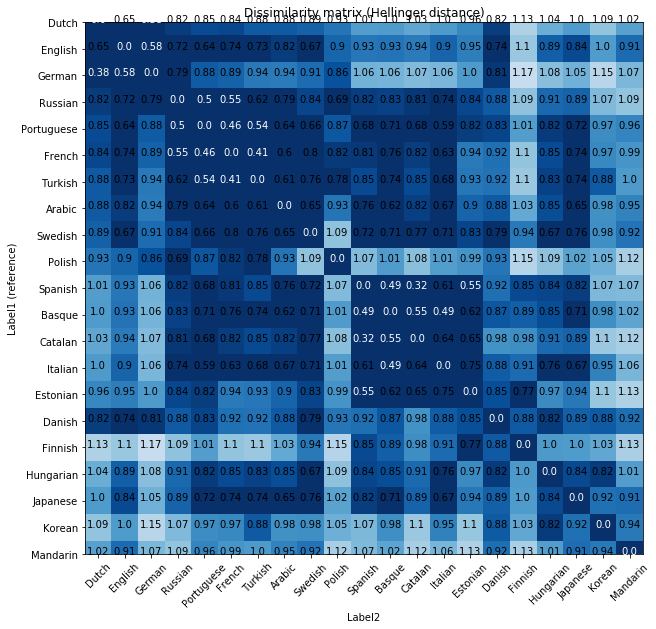

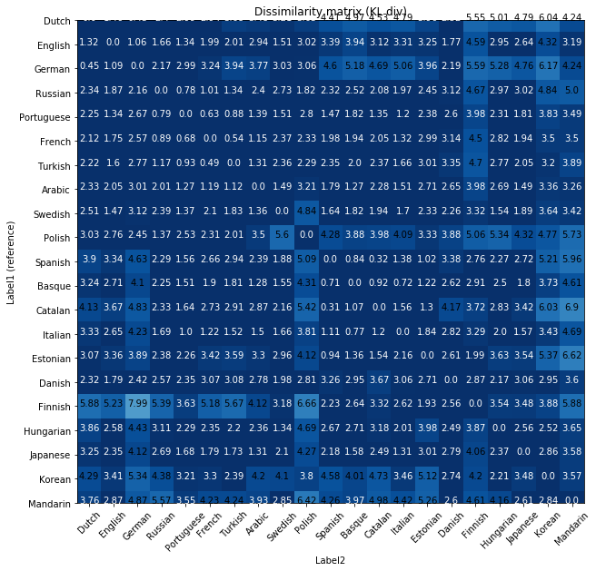

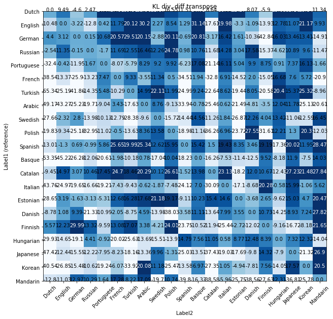

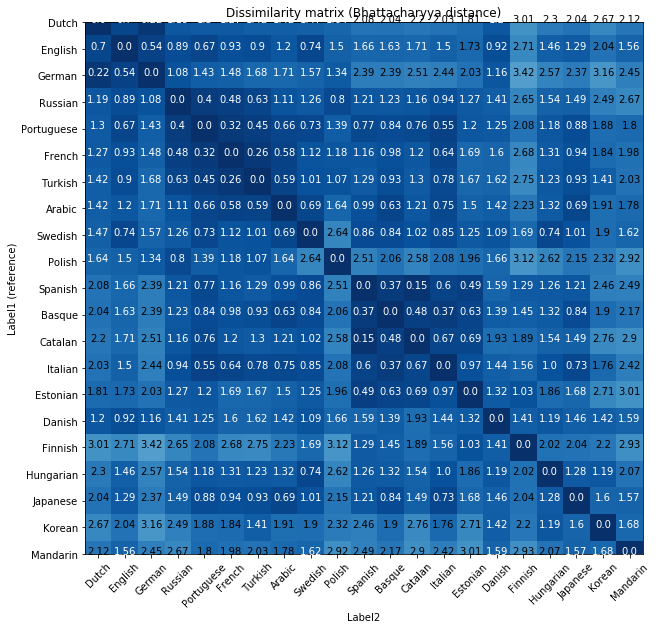

```python
def permut_mat(mat, permut=[1,2,5, 13,12,4,16,18, 15,11, 14,19,20,7, 17, 0, 3, 6, 8, 9, 10]):
    conf_matrix=mat
    conf_matrix_permut=np.zeros_like(conf_matrix)
    for i, ind in enumerate(permut):
        conf_matrix_permut[i]=conf_matrix[ind][permut]
    languages_permut=[languages[ind] for ind in permut]
    return languages_permut, conf_matrix_permut


if do_similarity_analyses:
    #pl.figure(figsize=(10, 10))
    #plot_distance_matrix(corr_matrix, languages, title='Correlation matrix', vmin=0.05, vmax=0.5)

    pl.figure(figsize=(10, 10))
    languages_permut, prox_d_hell_permut=permut_mat(prox_d_hell)
    plot_distance_matrix(prox_d_hell_permut, languages_permut, title='Dissimilarity matrix (Hellinger distance)', vmin=0.8, vmax=1.3)

    pl.figure(figsize=(10, 10))

    languages_permut, prox_d_kl_permut=permut_mat(prox_d_kl)
    plot_distance_matrix(prox_d_kl_permut, languages_permut, title='Dissimilarity matrix (KL div)', vmin=3, vmax=15)


    pl.figure(figsize=(10, 10))
    plot_distance_matrix( (prox_d_kl_permut-prox_d_kl_permut.T)/(prox_d_kl_permut+1e-3)*100, languages_permut, title='KL div, diff transpose', vmin=-20, vmax=20, invert_colors=True)


    pl.figure(figsize=(10, 10))
    languages_permut, prox_d_bhat_permut=permut_mat(prox_d_bhat)
    plot_distance_matrix(prox_d_bhat_permut, languages_permut, title='Dissimilarity matrix (Bhattacharyya distance)', vmin=0, vmax=8)
```

See http://scikit-learn.org/stable/modules/manifold.html#multidimensional-scaling

```
stress : 0.164924403026518
stress : 0.19061521671913212
    Danish	 actual dissimilarity: 55.578 	 difference: 13.557 	 percent diff.: 24.39 %
     Dutch	 actual dissimilarity: 75.111 	 difference: 11.570 	 percent diff.: 15.40 %
   English	 actual dissimilarity: 53.429 	 difference: 8.920 	 percent diff.: 16.70 %
   Finnish	 actual dissimilarity: 85.116 	 difference: 12.165 	 percent diff.: 14.29 %
    French	 actual dissimilarity: 44.158 	 difference: 6.488 	 percent diff.: 14.69 %
    German	 actual dissimilarity: 75.540 	 difference: 11.286 	 percent diff.: 14.94 %
 Hungarian	 actual dissimilarity: 58.934 	 difference: 9.734 	 percent diff.: 16.52 %
   Italian	 actual dissimilarity: 45.416 	 difference: 5.161 	 percent diff.: 11.36 %
  Japanese	 actual dissimilarity: 51.611 	 difference: 8.269 	 percent diff.: 16.02 %
    Korean	 actual dissimilarity: 76.616 	 difference: 13.818 	 percent diff.: 18.03 %
  Mandarin	 actual dissimilarity: 82.105 	 difference: 11.829 	 percent diff.: 14.41 %
    Polish	 actual dissimilarity: 74.312 	 difference: 8.101 	 percent diff.: 10.90 %
Portuguese	 actual dissimilarity: 40.621 	 difference: 6.419 	 percent diff.: 15.80 %
   Russian	 actual dissimilarity: 51.513 	 difference: 5.084 	 percent diff.: 9.87 %
   Spanish	 actual dissimilarity: 56.640 	 difference: 8.367 	 percent diff.: 14.77 %
   Swedish	 actual dissimilarity: 46.584 	 difference: 9.886 	 percent diff.: 21.22 %
   Turkish	 actual dissimilarity: 46.590 	 difference: 6.543 	 percent diff.: 14.04 %
  Estonian	 actual dissimilarity: 62.225 	 difference: 12.563 	 percent diff.: 20.19 %
    Arabic	 actual dissimilarity: 44.752 	 difference: 7.406 	 percent diff.: 16.55 %
    Basque	 actual dissimilarity: 46.494 	 difference: 5.228 	 percent diff.: 11.24 %
   Catalan	 actual dissimilarity: 64.099 	 difference: 10.686 	 percent diff.: 16.67 %
```

```
'\ncoord_pts = mds.fit_transform((dm_selected_modified.T+dm_selected_modified)/2)\n\nfig = pl.figure(figsize=(10,10))\nax = pl.gca()\nax.scatter(coord_pts[:,0], coord_pts[:,1])\n\nfor i, txt in enumerate(selected_languages):\n    ax.annotate(txt, coord_pts[i]+(delta, delta))\n\ndist_measure_str = "K…
```

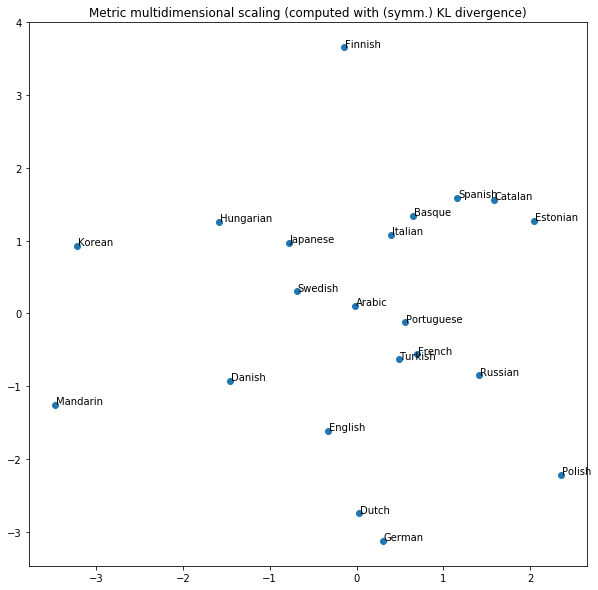

```python
import itertools
from sklearn import cluster
from sklearn import manifold
from sklearn.metrics import pairwise_distances

mds = manifold.MDS(n_components=2, metric=True,
                   verbose=0, dissimilarity='precomputed', n_init=10)

#NON METRIC
#mds = manifold.MDS(n_components=2, metric=False,
#                   n_init=30, max_iter=300,
#                   verbose=0, eps=0.001, dissimilarity='precomputed')





dist_measure_str = "Hellinger distance"
dm=prox_d_hell

dist_measure_str = "(symm.) KL divergence"
dm=prox_d_kl


languages2=languages
'''
print('not shown: Hungarian, Finnish, (and Polish?)')
#HACK delete hungarian
dm=np.delete(dm, 6, axis=0)
dm=np.delete(dm, 6, axis=1)
languages2=languages[0:6]+languages[7::]

#HACK delete Finnish
dm=np.delete(dm, 3, axis=0)
dm=np.delete(dm, 3, axis=1)
languages2=languages2[0:3]+languages2[4::]

#HACK delete Polish
dm=np.delete(dm, 9, axis=0)
dm=np.delete(dm, 9, axis=1)
languages2=languages2[0:9]+languages2[10::]
'''

coord_pts = mds.fit_transform((dm.T+dm)/2) #symmetrize if necessary
delta = 0.01

fig = pl.figure(figsize=(10,10))
ax = pl.gca()
ax.scatter(coord_pts[:,0], coord_pts[:,1])

for i, txt in enumerate(languages2):
    ax.annotate(txt, coord_pts[i]+(delta, delta))

pl.title("Metric multidimensional scaling (computed with {})".format(dist_measure_str))

pl.plot()


stress=np.sqrt(mds.stress_/(np.sum(dm**2)/2))

dm2=pairwise_distances(coord_pts)
stress2=np.sqrt(np.sum((dm2-dm)**2)/np.sum(dm**2))

print(f'stress : {stress}')

print(f'stress : {stress2}')

for i in range(len(languages2)):
    act_diss=dm[i]
    diff=(dm2[i]-dm[i])
    lang=languages2[i]
    print(f'{lang.rjust(10)}\t actual dissimilarity: {np.sum(act_diss):.3f} \t difference: {np.sum(np.abs(diff)):.3f} \t percent diff.: {np.sum(np.abs(diff))/np.sum(act_diss)*100:.2f} %')

'''
coord_pts = mds.fit_transform((dm_selected_modified.T+dm_selected_modified)/2)

fig = pl.figure(figsize=(10,10))
ax = pl.gca()
ax.scatter(coord_pts[:,0], coord_pts[:,1])

for i, txt in enumerate(selected_languages):
    ax.annotate(txt, coord_pts[i]+(delta, delta))

dist_measure_str = "KL divergence" if dist_measure == D_KL else "Hellinger distance"
pl.title("Metric multidimensional scaling (computed with {})".format(dist_measure_str))

pl.plot()
'''
```

Note: the 'hole' : Japanese, Mandarin, Korean, Polish

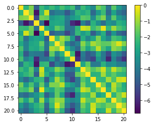

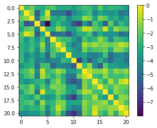

```python
pl.imshow(-dm2)
pl.colorbar()
pl.figure()
pl.imshow(-dm)
pl.colorbar()
```

Some clustering

```python
delta=10.
n_clusters = 6
spec_clustering = cluster.SpectralClustering(n_clusters=n_clusters,
                                          affinity="precomputed")
```

```python
if do_similarity_analyses:
    dm=(prox_d_kl+prox_d_kl.T)/2

    similarity_matrix=np.exp(- dm**2 / (2. * delta ** 2))
    clusters = spec_clustering.fit_predict(similarity_matrix)
    print("All languages : ")
    for i in range(n_clusters):
        cluster_labels = [languages[j] for j in np.where(clusters == i)[0]]
        print("> cluster {} : {} \n".format(i, cluster_labels))
```

```
All languages :
> cluster 0 : ['French', 'Hungarian', 'Italian', 'Portuguese', 'Russian', 'Spanish', 'Swedish', 'Turkish', 'Catalan']

> cluster 1 : ['Danish', 'Finnish', 'Estonian']

> cluster 2 : ['Korean']

> cluster 3 : ['Polish']

> cluster 4 : ['Japanese', 'Mandarin', 'Arabic', 'Basque']

> cluster 5 : ['Dutch', 'English', 'German']
```

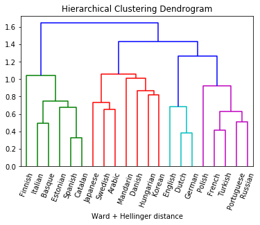

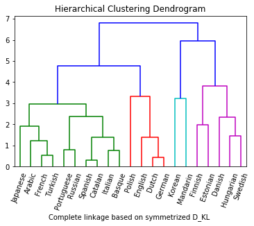

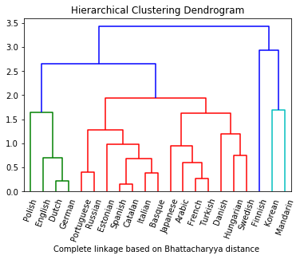

```python
plt=pl
def plot_dendrogram(model, **kwargs):
    # Create linkage matrix and then plot the dendrogram

    # create the counts of samples under each node
    counts = np.zeros(model.children_.shape[0])
    n_samples = len(model.labels_)
    for i, merge in enumerate(model.children_):
        current_count = 0
        for child_idx in merge:
            if child_idx < n_samples:
                current_count += 1  # leaf node
            else:
                current_count += counts[child_idx - n_samples]
        counts[i] = current_count

    linkage_matrix = np.column_stack([model.children_, model.distances_,
                                      counts]).astype(float)

    # Plot the corresponding dendrogram
    dendrogram(linkage_matrix, **kwargs)


if do_similarity_analyses:
    # Ward based on hist_act
    # setting distance_threshold=0 ensures we compute the full tree.
    model_clustering = cluster.AgglomerativeClustering(distance_threshold=0, n_clusters=None) #affinity='precomputed'


    #XXX hist_act or sqrt hist_act ??
    model_clustering = model_clustering.fit(np.sqrt(hist_act.T))
    plt.title('Hierarchical Clustering Dendrogram')


    # plot the dendrogram

    def labels_dendogram(k):
        return languages[k]

    plot_dendrogram(model_clustering, leaf_label_func=labels_dendogram, leaf_rotation=70)  #, truncate_mode='level', p=3
    plt.xlabel("Ward + Hellinger distance")
    plt.show()


    #DM  #try different linkage methods

    model_clustering = cluster.AgglomerativeClustering(distance_threshold=0, n_clusters=None, affinity='precomputed', linkage='complete' )

    dm=(prox_d_kl+prox_d_kl.T)/2

    model_clustering = model_clustering.fit(dm)   #if dm, needs to add affinity='precomputed' and change linkage method
    plt.title('Hierarchical Clustering Dendrogram')


    # plot the dendrogram

    def labels_dendogram(k):
        return languages[k]

    plot_dendrogram(model_clustering, leaf_label_func=labels_dendogram, leaf_rotation=70)  #, truncate_mode='level', p=3
    plt.xlabel("Complete linkage based on symmetrized D_KL ")
    plt.show()


    # Bhattacharyya distance

    model_clustering = cluster.AgglomerativeClustering(distance_threshold=0, n_clusters=None, affinity='precomputed', linkage='complete' )
    dm=prox_d_bhat
    #dm+=16*prox_d_hell

    model_clustering = model_clustering.fit(dm)   #if dm, needs to add affinity='precomputed' and change linkage method
    plt.title('Hierarchical Clustering Dendrogram')


    # plot the dendrogram


    plot_dendrogram(model_clustering, leaf_label_func=labels_dendogram, leaf_rotation=70)  #, truncate_mode='level', p=3
    plt.xlabel("Complete linkage based on Bhattacharyya distance ")
    plt.show()
```

from scipy.cluster.hierarchy import linkage #test scipy algorithm instead Z = linkage(np.sqrt(hist_act.T), method='complete') dn = dendrogram(Z, leaf_label_func=labels_dendogram, leaf_rotation=70) pl.show()

### Confusion matrix

```python
max_batchs=np.infty

if compute_confusion_matrix:
    nb_batchs_iter=min(networkInput.nbr_batchs, max_batchs)
    gen_batchs=iter(networkInput.sliced_batch.take(networkInput.num_slices_by_example*nb_batchs_iter))

    #lang_true=[]
    #lang_predicted=[]

    conf_matrix=np.zeros((len(languages), len(languages)))
    conf_matrix_filtered=np.zeros((len(languages_test), len(languages_test)))

    i_batch=0
    while(i_batch<nb_batchs_iter):
        #batch=networkInput.sliced_batch.take(networkInput.num_slices_by_example) #defined with generator instead
        batch=[next(gen_batchs) for slice_ in range(networkInput.num_slices_by_example)]
        model.reset_states()

        for trueBatch in batch:
            x, y, w= trueBatch
            filenames=x[2]
            y_=model(trueBatch, training=force_dropout_conf_matrix)  #training=False

        y=y.numpy()[:,-1]
        y_=y_.numpy()[:,-1]

        for j in range(batch_size):
            ind0=np.argmax(y[j])
            ind=np.argmax(y_[j])

            lang0=languages[ind0]
            lang=languages[ind]

            #lang_true.append(lang0)
            #lang_predicted.append(lang)

            conf_matrix[ind0][ind]+=1



            ind0bis=np.argmax(y[j][inds_lang_test])
            indbis=np.argmax(y_[j][inds_lang_test])

            conf_matrix_filtered[ind0bis][indbis]+=1





        i_batch+=1
```

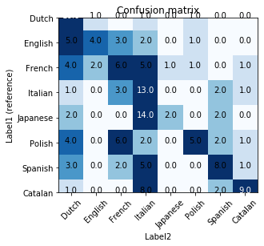

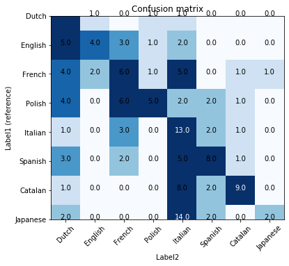

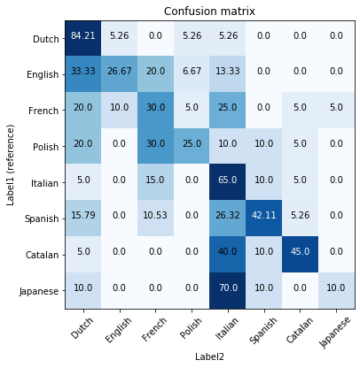

```python
if compute_confusion_matrix:

    #plot_distance_matrix(conf_matrix, languages, vmin=0, vmax=20,  normalize=True, invert_colors=True)

    permut=[1,2,5, 13,12,4,16,18, 15,11, 14,19,20,7, 17, 0, 3, 6, 8, 9, 10]

    conf_matrix_permut=np.zeros_like(conf_matrix)
    for i, ind in enumerate(permut):
        conf_matrix_permut[i]=conf_matrix[ind][permut]
    languages_permut=[languages[ind] for ind in permut]

    if useRamus:
        plot_distance_matrix(conf_matrix_filtered, languages_test, vmin=0, vmax=5, invert_colors=True,title='Confusion matrix')
        permut=[0,1,2,5,3,6,7, 4]
        conf_matrix_filtered_permut=np.zeros_like(conf_matrix_filtered)
        for i, ind in enumerate(permut):
            conf_matrix_filtered_permut[i]=conf_matrix_filtered[ind][permut]
        languages_test_permut=[languages_test[ind] for ind in permut]
        pl.figure(figsize=(6,6))

        pl.ylim([7.5, -0.5])
        plot_distance_matrix(conf_matrix_filtered_permut, languages_test_permut , vmin=0, vmax=5, invert_colors=True, title='Confusion matrix')
        pl.figure(figsize=(6,6))
        plot_distance_matrix(conf_matrix_filtered_permut, languages_test_permut , normalize=True, vmin=0, vmax=50, invert_colors=True, title='Confusion matrix')

        pl.ylim([7.5, -0.5])
    else:
        pl.figure(figsize=(15,15))
        plot_distance_matrix(conf_matrix_permut, languages_permut , normalize=True, vmin=0, vmax=10, invert_colors=True, title='Confusion matrix')

        pl.ylim([20.5, -0.5])
```